```r
render_html()
```

# 2d graphs

These 2d examples are both from Winsong Chang's excellent [R Graphics Cookbook](http://www.amazon.com/R-Graphics-Cookbook-Winston-Chang/dp/1449316956)

## Correlation Matrix Example

### Correlation plot

[figure not shown]

```r
library(corrplot)
corrplot(mcor)
```

### Regular R output

```r
# for the dataset
library(ggplot2)
rm(mtcars)
mcor <- cor(mtcars)
# Print mcor and round to 2 digits
round(mcor, digits = 2)
```

```
##        mpg   cyl  disp    hp  drat    wt  qsec    vs    am  gear  carb
## mpg   1.00 -0.85 -0.85 -0.78  0.68 -0.87  0.42  0.66  0.60  0.48 -0.55
## cyl  -0.85  1.00  0.90  0.83 -0.70  0.78 -0.59 -0.81 -0.52 -0.49  0.53
## disp -0.85  0.90  1.00  0.79 -0.71  0.89 -0.43 -0.71 -0.59 -0.56  0.39
## hp   -0.78  0.83  0.79  1.00 -0.45  0.66 -0.71 -0.72 -0.24 -0.13  0.75
## drat  0.68 -0.70 -0.71 -0.45  1.00 -0.71  0.09  0.44  0.71  0.70 -0.09
## wt   -0.87  0.78  0.89  0.66 -0.71  1.00 -0.17 -0.55 -0.69 -0.58  0.43
## qsec  0.42 -0.59 -0.43 -0.71  0.09 -0.17  1.00  0.74 -0.23 -0.21 -0.66
## vs    0.66 -0.81 -0.71 -0.72  0.44 -0.55  0.74  1.00  0.17  0.21 -0.57
## am    0.60 -0.52 -0.59 -0.24  0.71 -0.69 -0.23  0.17  1.00  0.79  0.06
## gear  0.48 -0.49 -0.56 -0.13  0.70 -0.58 -0.21  0.21  0.79  1.00  0.27
## carb -0.55  0.53  0.39  0.75 -0.09  0.43 -0.66 -0.57  0.06  0.27  1.00
```

### HTML table using xtable

```r
library(xtable)
print(xtable(mcor), type = "html")
```

|  | mpg | cyl | disp | hp | drat | wt | qsec | vs | am | gear | carb |
| --- | --- | --- | --- | --- | --- | --- | --- | --- | --- | --- | --- |
| mpg | 1.00 | -0.85 | -0.85 | -0.78 | 0.68 | -0.87 | 0.42 | 0.66 | 0.60 | 0.48 | -0.55 |
| cyl | -0.85 | 1.00 | 0.90 | 0.83 | -0.70 | 0.78 | -0.59 | -0.81 | -0.52 | -0.49 | 0.53 |
| disp | -0.85 | 0.90 | 1.00 | 0.79 | -0.71 | 0.89 | -0.43 | -0.71 | -0.59 | -0.56 | 0.39 |
| hp | -0.78 | 0.83 | 0.79 | 1.00 | -0.45 | 0.66 | -0.71 | -0.72 | -0.24 | -0.13 | 0.75 |
| drat | 0.68 | -0.70 | -0.71 | -0.45 | 1.00 | -0.71 | 0.09 | 0.44 | 0.71 | 0.70 | -0.09 |
| wt | -0.87 | 0.78 | 0.89 | 0.66 | -0.71 | 1.00 | -0.17 | -0.55 | -0.69 | -0.58 | 0.43 |
| qsec | 0.42 | -0.59 | -0.43 | -0.71 | 0.09 | -0.17 | 1.00 | 0.74 | -0.23 | -0.21 | -0.66 |
| vs | 0.66 | -0.81 | -0.71 | -0.72 | 0.44 | -0.55 | 0.74 | 1.00 | 0.17 | 0.21 | -0.57 |
| am | 0.60 | -0.52 | -0.59 | -0.24 | 0.71 | -0.69 | -0.23 | 0.17 | 1.00 | 0.79 | 0.06 |
| gear | 0.48 | -0.49 | -0.56 | -0.13 | 0.70 | -0.58 | -0.21 | 0.21 | 0.79 | 1.00 | 0.27 |
| carb | -0.55 | 0.53 | 0.39 | 0.75 | -0.09 | 0.43 | -0.66 | -0.57 | 0.06 | 0.27 | 1.00 |

## Network Graph Example ##

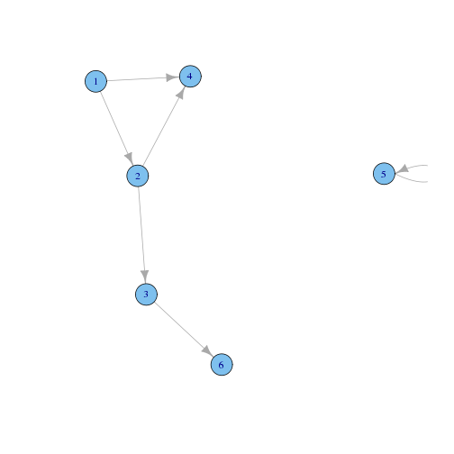

```r
library(igraph)
# Specify edges for a directed graph
gd <- graph(c(1, 2, 2, 3, 2, 4, 1, 4, 5, 5, 3, 6))
plot(gd)
```

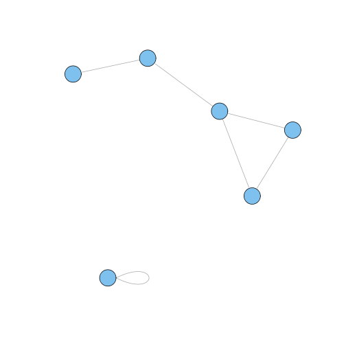

```r
# For an undirected graph
gu <- graph(c(1, 2, 2, 3, 2, 4, 1, 4, 5, 5, 3, 6), directed = FALSE)
# No labels
plot(gu, vertex.label = NA)
```

# 3d graphs

This example is from [Yihui's response](http://stackoverflow.com/questions/14879210/including-a-interactive-3d-figure-with-knitr) to a stack overflow question.

Need to load the CanvasMatrix library and the hook_webgl code to get 3d graphs to work

```r
has_X11 = Sys.getenv("DISPLAY") != ""
if (has_X11) knit_hooks$set(webgl = hook_webgl)
```

```html
<script src="https://dl.dropbox.com/u/15335397/misc/CanvasMatrix.js"></script>
```

## point 3d graph

```r
library(rgl)
x <- sort(rnorm(1000))
y <- rnorm(1000)
z <- rnorm(1000) + atan2(x, y)
plot3d(x, y, z, col = rainbow(1000))
```

[interactive chart not shown]

You must enable Javascript to view this page properly.

## spheres 3d graph

```r
open3d()
```

```
## [1] 2
```

```r
spheres3d(x, y, z, col = rainbow(1000))
```

[interactive chart not shown]

You must enable Javascript to view this page properly.

Author: [Jim Hester](http://jimhester.com) Created: 2013 Mar 27 10:54:38 PM Last Modified: 2013 Apr 23 02:24:13 PM

# Cars example

from [statmethods.net](http://www.statmethods.net/advgraphs/ggplot2.html)

```r
render_html()
# ggplot2 examples
library(ggplot2)
rm(mtcars)
# use color brewer as default discrete colors
scale_colour_discrete <- function(...) scale_color_brewer(palette = "Set1",
    ...)
scale_fill_discrete <- function(...) scale_fill_brewer(palette = "Set1", ...)

# create factors with value labels
mtcars$gear <- factor(mtcars$gear, levels = c(3, 4, 5), labels = c("3gears",
    "4gears", "5gears"))
mtcars$am <- factor(mtcars$am, levels = c(0, 1), labels = c("Automatic", "Manual"))
mtcars$cyl <- factor(mtcars$cyl, levels = c(4, 6, 8), labels = c("4cyl", "6cyl",
    "8cyl"))
```

## Kernel density plots for mpg

grouped by number of gears (indicated by color)

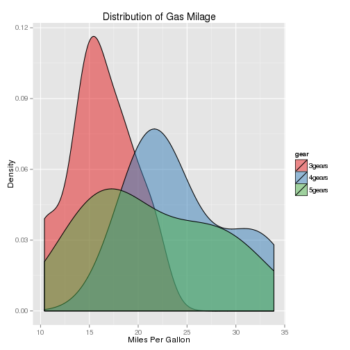

```r
qplot(mpg, data = mtcars, geom = "density", fill = gear, alpha = I(0.5), main = "Distribution of Gas Milage",
    xlab = "Miles Per Gallon", ylab = "Density")
```

## Scatterplot of mpg vs. hp

for each combination of gears and cylinders in each facet, transmission type is represented by shape and color

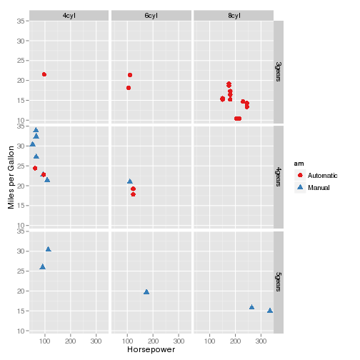

```r
qplot(hp, mpg, data = mtcars, shape = am, color = am, facets = gear ~ cyl, size = I(3),
    xlab = "Horsepower", ylab = "Miles per Gallon")
```

## Regressions of mpg on weight

Seperate for each number of cylinders

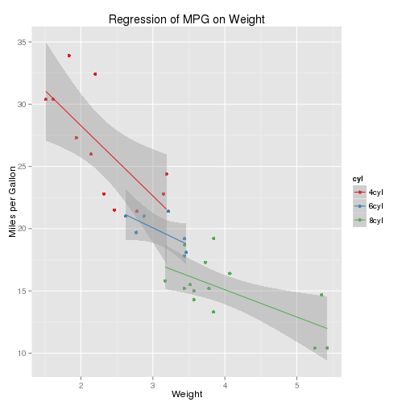

```r
qplot(wt, mpg, data = mtcars, geom = c("point", "smooth"), method = "lm", formula = y ~
    x, color = cyl, main = "Regression of MPG on Weight", xlab = "Weight", ylab = "Miles per Gallon")
```

## Boxplots of mpg by number of gears

observations (points) are overlayed and jittered

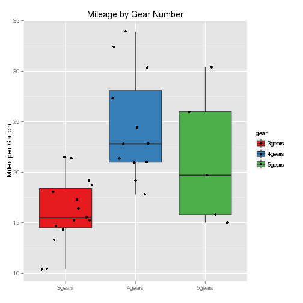

```r
qplot(gear, mpg, data = mtcars, geom = c("boxplot", "jitter"), fill = gear,
    main = "Mileage by Gear Number", xlab = "", ylab = "Miles per Gallon")
```

Author: [Jim Hester](http://jimhester.com) Created: 2013 Mar 20 10:57:07 AM Last Modified: 2013 Apr 26 11:37:19 AM

# Other Languages

## R

```r
print("hello world")
```

```
## [1] "hello world"
```

## Bash

```bash
echo "hello world"
```

```
## hello world
```

## Perl

```perl
print "hello world\n";
```

```
## hello world
```

```
## Error: cannot open the connection
```

## Ruby

```ruby
puts "hello world"
```

```
## hello world
```

## Python

```python
print "hello world"
```

```
## hello world
```

Author: [Jim Hester](http://jimhester.com) Created: 2013 Apr 23 09:05:58 AM Last Modified: 2013 Apr 26 11:21:00 AM

# Illusions

The R implementations for these are from Kohske Takahashi[(@kohske)](https://twitter.com/kohske). See http://rpubs.com/kohske/R-de-illusion from [statmethods.net](http://www.statmethods.net/advgraphs/ggplot2.html)

## Café wall illusion

All the lines are actually parallel

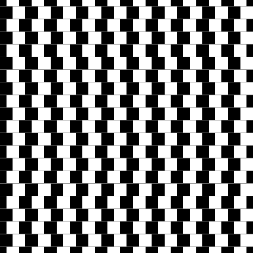

```r
library(grid)
rs <- expand.grid(x = seq(0, 1, 1/10), y = seq(0, 1, 1/10))
grid.rect(rs$x, rs$y, 1/10/2, 1/10/2, gp = gpar(fill = "black", col = NA))
grid.rect(rs$x + 1/10/4, rs$y + 1/10/2, 1/10/2, 1/10/2, gp = gpar(fill = "black",
    col = NA))
ls <- expand.grid(x = 0:1, y = seq(0, 1, 1/20) - 1/20/2)
grid.polyline(ls$x, ls$y, id = gl(nrow(ls)/2, 2), gp = gpar(col = "grey50",
    lwd = 1))
```

## Ouchi

Move your frame of reference to see the effect.

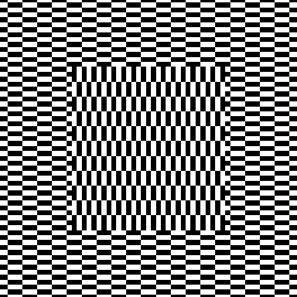

```r
grid.newpage()
nx <- 10
ny <- 30
rs <- expand.grid(x = seq(0, 1, 1/nx/2), y = seq(0, 1, 1/ny/2))
grid.rect(rs$x, rs$y, 1/nx/2, 1/ny/2, gp = gpar(col = NA, fill = c("black",
    "white")))
rs <- expand.grid(x = seq(0.25, 0.75, 1/nx/2), y = seq(0.25, 0.75, 1/ny/2))
grid.rect(rs$y, rs$x, 1/ny/2, 1/nx/2, gp = gpar(col = NA, fill = c("black",
    "white")))
```

## Fraser illusion

All the lines are actually parallel

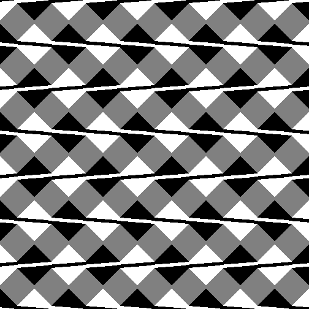

```r
library(plyr)
grid.newpage()
n <- 10
ny <- 8
L <- 0.01
c <- seq(0, 1, length = n)
d <- 1.2 * diff(c)[1]/2
col <- c("black", "white")
x <- c(c - d, c, c + d, c)
y <- rep(c(0, -d, 0, d), each = n)
w <- c(c - d, c - d + L, c + d, c + d - L)
z <- c(0, L, 0, -L)
ys <- seq(0, 1, length = ny)
grid.rect(gp = gpar(fill = gray(0.5), col = NA))
l_ply(1:ny, function(i) {
    n
    if (i%%2 == 0) {
        co <- rev(col)
        z <- -z
    } else {
        co <- col
    }
    grid.polygon(x, y + ys[i], id = rep(1:n, 4), gp = gpar(fill = co, col = NA))
    grid.polygon(w, rep(z, each = n) + ys[i], id = rep(1:n, 4), gp = gpar(fill = rev(co),
        col = NA))
})
```

## Fraser-Wilcox illusion

[figure not shown]

```r
grid.newpage()
No <- 3
wo <- 1/3/2
po <- seq(0, 1, by = wo)[(1:No) * 2]
Nc <- 8
tc <- seq(pi * 11/12, pi * 1/12, len = Nc)
px <- c(outer(wo * cos(tc), po, `+`))
wc <- rep(sin(tc), No)
ag <- rep(1:No, each = Nc)
dc <- 21
th <- seq(0, 2 * pi, len = dc)
grid.rect(gp = gpar(col = NA, fill = "#D2D200"))
for (y0 in seq(0, 1, len = 10)) {
    for (i in seq_along(px)) {
        th <- seq(pi/2, pi/2 + 2 * pi, len = 21)
        if (ag[i]%%2 == 0)
            th <- rev(th)
        x <- px[i] + 0.5 * 0.04 * cos(th) * wc[i]
        y <- y0 + 0.04 * sin(th)
        grid.polygon(x, y, gp = gpar(fill = "#3278FE"))
        grid.polyline(x[1:((dc + 1)/2)], y[1:((dc + 1)/2)], gp = gpar(lineend = "butt",
            lwd = 3, col = gray(0)))
        grid.polyline(x[-(1:((dc - 1)/2))], y[-(1:((dc - 1)/2))], gp = gpar(lineend = "butt",
            lwd = 3, col = gray(1)))
    }
}
```

## Parallel curves

These curves are the same offset apart for every x, even though it looks like they converge.

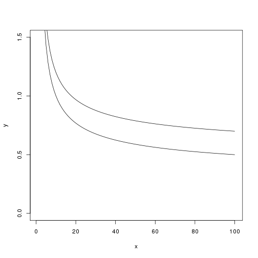

```r
x = 1:100
y = 1/log10(x)
y2 = y + 0.2
plot(x, y, type = "l", ylim = c(0, 1.5))
lines(x, y2)
```

# Map plots

## USA Arrests

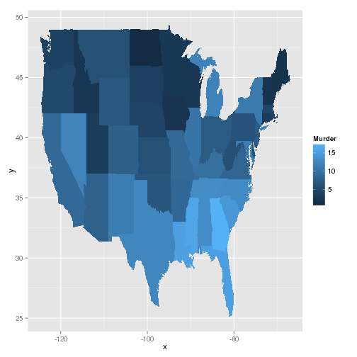

```r
library(ggplot2)
crimes <- data.frame(state = tolower(rownames(USArrests)), USArrests)
library(reshape2)  # for melt
crimesm <- melt(crimes, id = 1)
require(maps)
states_map <- map_data("state")
ggplot(crimes, aes(map_id = state)) + geom_map(aes(fill = Murder), map = states_map) +
    expand_limits(x = states_map$long, y = states_map$lat)
```

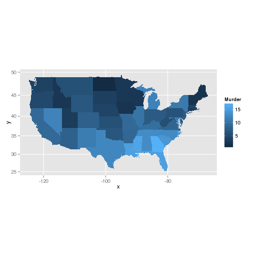

```r
last_plot() + coord_map()
```

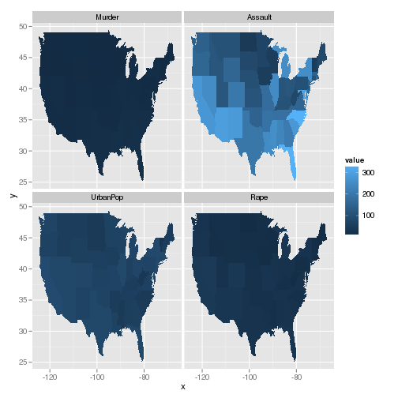

```r
ggplot(crimesm, aes(map_id = state)) + geom_map(aes(fill = value), map = states_map) +
    expand_limits(x = states_map$long, y = states_map$lat) + facet_wrap(~variable)
```

### Use fig.show='hold'

These are the same plots with fig.show='hold' in the options

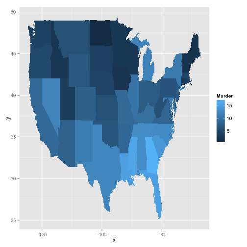

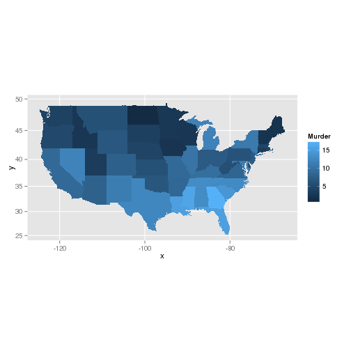

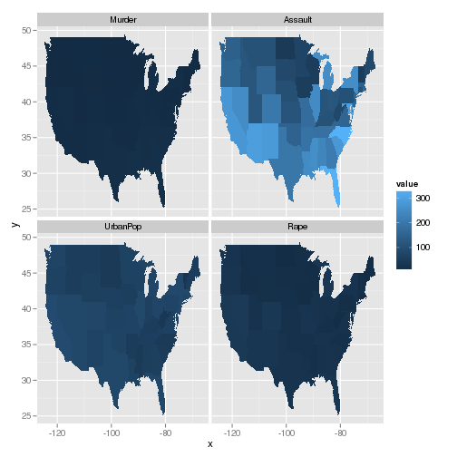

```r
ggplot(crimes, aes(map_id = state)) + geom_map(aes(fill = Murder), map = states_map) +
    expand_limits(x = states_map$long, y = states_map$lat)
last_plot() + coord_map()
ggplot(crimesm, aes(map_id = state)) + geom_map(aes(fill = value), map = states_map) +
    expand_limits(x = states_map$long, y = states_map$lat) + facet_wrap(~variable)
```

Author: [Jim Hester](http://jimhester.com) Created: 2013 Mar 28 02:44:48 PM Last Modified: 2013 Mar 28 03:33:39 PM

# Math expressions

[MathJax](http://www.mathjax.org/demos/tex-samples) examples

## simple

\[\alpha+\beta=\gamma\]

## The Lorenz Equations

\[\begin{aligned} \dot{x} & = \sigma(y-x) \\ \dot{y} & = \rho x - y - xz \\ \dot{z} & = -\beta z + xy \end{aligned} \]

## Coins

The probability of getting \(k\) heads when flipping \(n\) coins is \[P(E) = {n \choose k} p^k (1-p)^{ n-k} \]

## An Identity of Ramanujan

\[ \frac{1}{\Bigl(\sqrt{\phi \sqrt{5}}-\phi\Bigr) e^{\frac25 \pi}} = 1+\frac{e^{-2\pi}} {1+\frac{e^{-4\pi}} {1+\frac{e^{-6\pi}} {1+\frac{e^{-8\pi}} {1+\ldots} } } } \]

Author: [Jim Hester](http://jimhester.com) Created: 2013 Apr 01 03:27:26 PM Last Modified: 2013 Apr 23 02:24:32 PM

Author: [Jim Hester](http://jimhester.com) Created: 2013 Mar 28 03:22:28 PM Last Modified: 2013 Apr 26 12:02:04 PM